# AEDV - Lista 1 - Atividade A: Quarteto de Anscombe

Pedro Henrique Coterli

2023-05-11

Para o primeiro exercício, primeiramente, é claro, eu instalei e ativei a biblioteca do ggplot2. Em seguida, encontrei a biblioteca “datasets”, que possuía uma tabela com os dados do Quarteto de Anscombe. Assim, instalei ela e salvei essa tabela em uma variável.

```
install.packages('ggplot2')
library(ggplot2)
install.packages('datasets')
library(datasets)

ans = datasets::anscombe
```

Em seguida, comecei a gerar os 4 gráficos de dispersão utilizando as funções `ggplot` e `geom_point`.

```
graph1 = ggplot(ans, aes(x = x1, y = y1)) + geom_point()
```

O mesmo eu fiz para os outros 3 gráficos.  
Em seguida, adicionei a linha de dispersão utilizando a função `geom_smooth`.

```
graph1 = graph1 + geom_smooth(method = 'lm', se = FALSE)
```

Após isso, alterei os títulos dos eixos e inseri títulos simples aos gráficos (apenas por questão estética).

```
graph1 = graph1 + xlab('x') + ylab('y') + ggtitle('Gráfico 1')
```

Por fim, para deixar mais evidente a semelhança entre as estatísticas dos dados, configurei os intervalos dos eixos para que todos os gráficos ficassem com as mesmas proporções e inseri um ponto vermelho referente às coordenadas das médias de x e de y.

```
graph1 = graph1 + xlim(4, 19) + ylim(3, 13) + geom_point((aes(x = mean(ans[,1]), y = mean(ans[,5])), colour = "red", size = 2))
```

Agora, para unir os 4 gráficos em uma única imagem, encontrei um pacote chamado “patchwork”, instalei-o e gerei a imagem final.

```
install.packages('patchwork')
library(patchwork)

graph1 + graph2 + graph3 + graph4
```

O código mais resumido e compilado está logo abaixo:

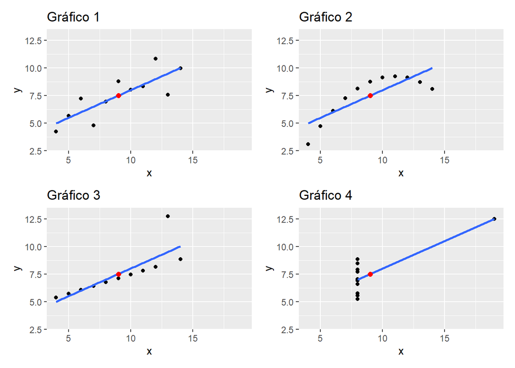

```r
if(!require(ggplot2)) install.packages("ggplot2", repos = "http://cran.us.r-project.org")
if(!require(datasets)) install.packages("datasets", repos = "http://cran.us.r-project.org")
if(!require(patchwork)) install.packages("patchwork", repos = "http://cran.us.r-project.org")
library(ggplot2)
library(datasets)
library(patchwork)

ans = datasets::anscombe

graph1 = ggplot(ans, aes(x = x1, y = y1)) + geom_point() + geom_smooth(method = 'lm', se = FALSE) + xlab('x') + ylab('y') + ggtitle('Gráfico 1') + xlim(4, 19) + ylim(3, 13) + geom_point(aes(x = mean(ans[,1]), y = mean(ans[,5])), colour = "red", size = 2)

graph2 = ggplot(ans, aes(x = x2, y = y2)) + geom_point() + geom_smooth(method = 'lm', se = FALSE) + xlab('x') + ylab('y') + ggtitle('Gráfico 2') + xlim(4, 19) + ylim(3, 13) + geom_point(aes(x = mean(ans[,2]), y = mean(ans[,6])), colour = "red", size = 2)

graph3 = ggplot(ans, aes(x = x3, y = y3)) + geom_point() + geom_smooth(method = 'lm', se = FALSE) + xlab('x') + ylab('y') + ggtitle('Gráfico 3') + xlim(4, 19) + ylim(3, 13) + geom_point(aes(x = mean(ans[,3]), y = mean(ans[,7])), colour = "red", size = 2)

graph4 = ggplot(ans, aes(x = x4, y = y4)) + geom_point() + geom_smooth(method = 'lm', se = FALSE) + xlab('x') + ylab('y') + ggtitle('Gráfico 4') + xlim(4, 19) + ylim(3, 13) + geom_point(aes(x = mean(ans[,4]), y = mean(ans[,8])), colour = "red", size = 2)

graph1 + graph2 + graph3 + graph4
```